# Lista 01

Geisielen Gomes

2026-04-22

## Questão 1

```r
mat <- 650
mat%%3
```

```
## [1] 2
```

A distruição usada será Gumbell
$$F(x;\mu,
\beta) = e^{-e^{-(x-\mu)/\beta}}$$

A função quantílica é dada por :

$$u= e^{-e^{-(x-\mu)/\beta}}$$
$$\ln(u)=-e^{-(x-\mu)/\beta}$$
$$-\ln(u)=e^{-(x-\mu)/\beta}$$
$$\ln(-\ln(u))=-\frac{x-\mu}{\beta}$$
$$-\ln(-\ln(u))=\frac{x-\mu}{\beta}$$
$$x=\mu-ln(-ln(u))\beta$$

Para definir a função de gerador de números aleatórios fizemos :

```r
mu <- 0
b <- 1

gera_gum <- function(mu,b,n){
  u <- runif(n,min = 0, max = 1)
  x <- mu - b * log(-log(u))
  return (x)
}
amostra<- gera_gum(mu,b,1000)
amostra
```

[output not shown]

[output cut: 185 more lines]

Agora vamos ver como esse números se comportam :

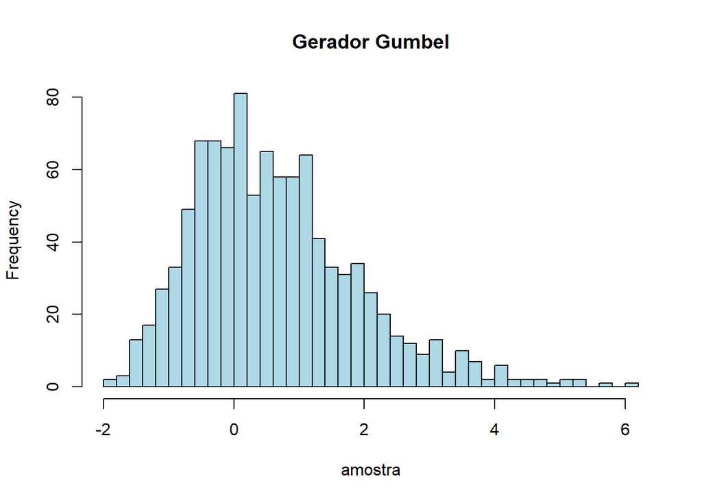

```r
hist(amostra, breaks = 30, main = "Gerador Gumbel", col = "lightblue")
```

Nós percebemos que ela tem a assimetria caracteristica de uma distribuição Gumbell , mas para confirmamos nossa hipotese faremos :

```r
p_gumbel <- function(x, mu, b) {
  exp(-exp(-(x - mu) / b))
}
print(ks.test(amostra, p_gumbel, mu = mu, b = b))
```

```
##
##  Asymptotic one-sample Kolmogorov-Smirnov test
##
## data:  amostra
## D = 0.041356, p-value = 0.06538
## alternative hypothesis: two-sided
```

## Questão 2

Utilizando o mesmo método da ultima questão chegamos que

$$u=\frac{x^2+x}{2}\\
2u=x^2 +x\\
x^2+x-2u=0$$

Procurando as raízes dessa equação chegamos em

$$x=\frac{-1+\sqrt{1+8u}}{2}$$

Escolhemos essa raiz porque a outra raíz chegariamos em valores negativos o que seria uma contradiçõ já uma fdp só resulta em valores positivos .

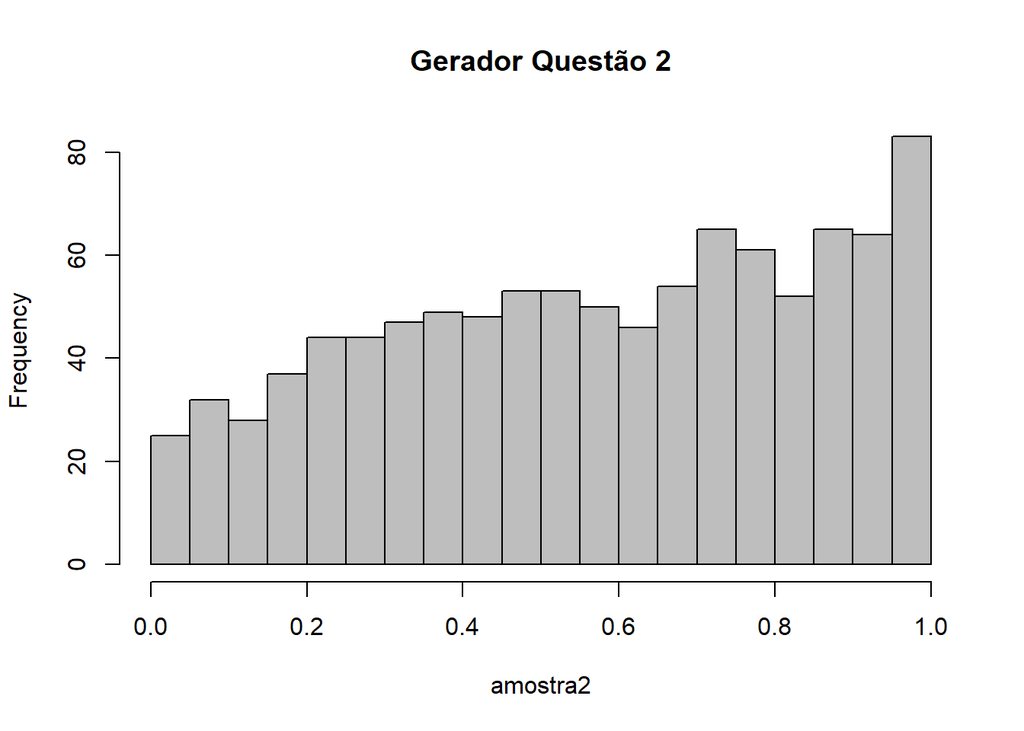

```r
gera_2 <- function(n){
  u <- runif(n,min = 0,max=1)
  x <- (-1+ (1+8*u)^(1/2))/2
  return(x)
}
amostra2 <- gera_2(1000)
hist(amostra2, breaks = 30, main = "Gerador Questão 2", col = "gray")
```

## Questão 3

Do enunciado temos que :

$$f_x(x)=\exp^{-2\left|x \right|}$$

A acumulada dessa função é dada por

Criando um gerador baseado nessas informações temos

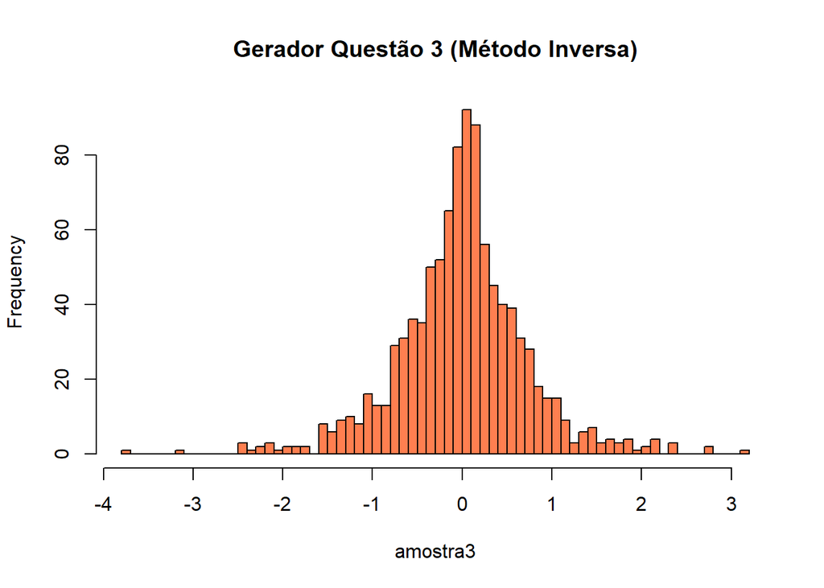

```r
gera_3 <- function(n) {
  u <- runif(n)

  x <- ifelse(u <= 0.5,
              log(2 * u) / 2,
              -log(2 * (1 - u)) / 2
       )

  return(x)
}
amostra3 <- gera_3(1000)
hist(amostra3, breaks = 50, col = "coral", main = "Gerador Questão 3 (Método Inversa)")
```

## Questão 4

```r
gera_4 <- function(n){
  u <- runif(n)
  x <- log(u/(1-u))
  return(x)
}
amostra4 <- gera_4(1e3)
ks.test(amostra4, "plogis", location = 0, scale = 1)
```

```
##
##  Asymptotic one-sample Kolmogorov-Smirnov test
##
## data:  amostra4
## D = 0.022671, p-value = 0.6829
## alternative hypothesis: two-sided
```

Depois de ter gerado esse conjunto efazer o teste de kolmogorov ele não nos uma informação que nos dê poder para concluir que os numeros gerados resultam numa logistica (0,1) então por isso faremos o teste da qui- quadrado . Para fazermos esse teste nós faremos a variável `quebras` onde colocamos 10% dos dados em cada faixa criada , ou seja , temos 10 faixas no chisq.teste estamos esperando que tenha 100 números em cada um dos intervalos .

```r
quebras <- qlogis(seq(0, 1, by = 0.1))
contagem_obs <- table(cut(amostra4, breaks = quebras, include.lowest = TRUE))
chisq.test(contagem_obs)
```

```
##
##  Chi-squared test for given probabilities
##
## data:  contagem_obs
## X-squared = 7.92, df = 9, p-value = 0.5422
```

para exemplificar isso vamos fazer definindo esses parâmetros e vamos comparar com o gráficos logistica nesses parâmetros

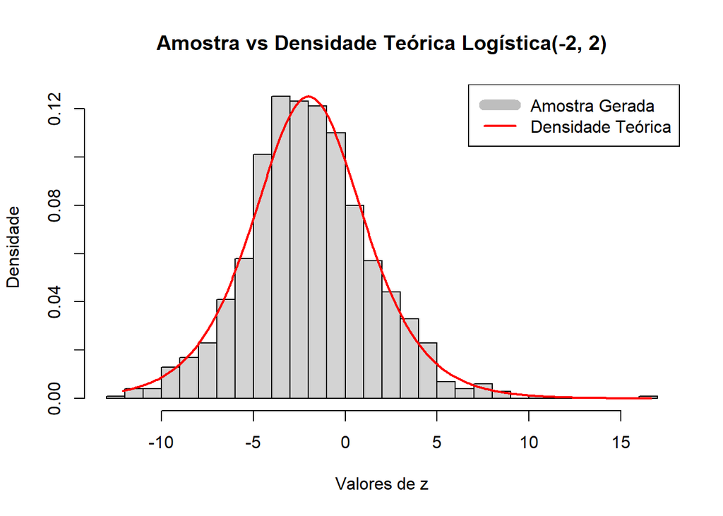

```r
z <- -2+amostra4*2
hist(z, breaks = 40, freq = FALSE, col = "lightgrey",
     main = "Amostra vs Densidade Teórica Logística(-2, 2)",
     xlab = "Valores de z", ylab = "Densidade")
x_seq <- seq(min(z), max(z), length.out = 500)
y_teorico <- dlogis(x_seq, location = -2, scale = 2)
lines(x_seq, y_teorico, col = "red", lwd = 2)
legend("topright", legend = c("Amostra Gerada", "Densidade Teórica"),
       col = c("grey", "red"), lwd = c(10, 2))
```

## Questão 5

Para respondermos essa questão nós vamos fixar $\alpha$ e usar dois métodos pra gerar a Uniforme(0,$\alpha$). Primeiro vamos usar o método da Transformação onde basicamente estamos “adicionando” um parâmetro de escala

```r
alpha <- 0.9
z1 <-alpha*runif(1e3)
```

E o outra forma que faremos isso é usando o método da rejeição :

```r
alpha <- 0.9


rejt <- function(n, alpha){

  x <- numeric(n)  # vetor para guardar resultados
  i <- 1

  while(i <= n){

    u <- runif(1)

    if(u < alpha){   # aceita somente se u < alpha
      x[i] <- u
      i <- i + 1
    }

  }

  return(x)
}

z2 <- rejt(1e3, alpha)
```

Comparando os dois métodos :

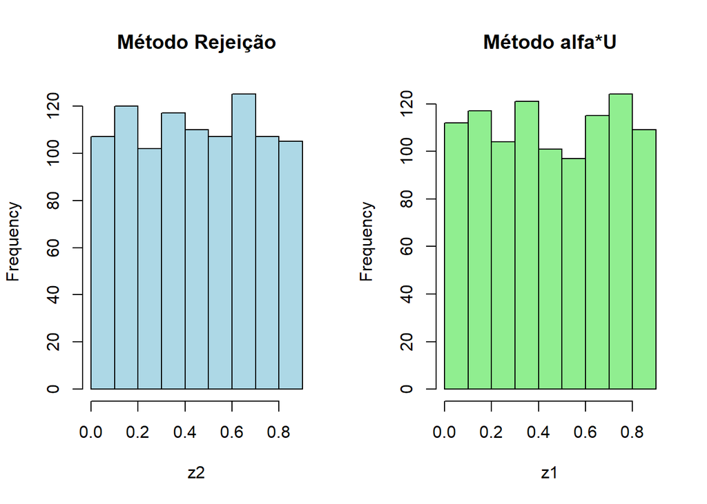

```r
par(mfrow=c(1,2))
hist(z2, main="Método Rejeição", col="lightblue")
hist(z1, main="Método alfa*U", col="lightgreen")
```

## Questão 6

```r
m <-  2^(13) - 1
a <-  17
xo <- 2
gera6 <- function(n,m,a,xo){
  v <- numeric(n)
  xn <- xo
  for (i in 1:n) {
    xn <- (a * xn) %% m
    v[i] <- xn

  }
  return(v/m)#precisamos dividir por m porque assim garntimos que 0<v<1

}
x6 <- gera6(500,m,a,xo)
#c , d
x_i <- x6[1:499]
x_proximo <- x6[2:500]
cat("A covariância é ", cor(x_i, x_proximo))
```

```
## A covariância é  0.1080907
```

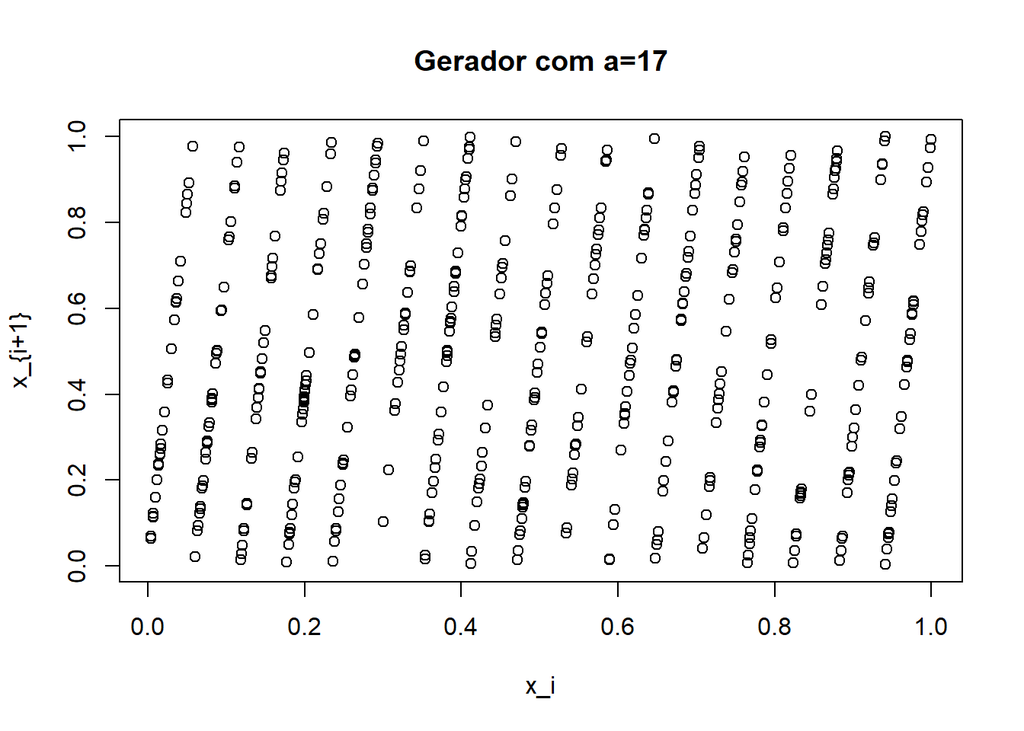

```r
plot(x_i, x_proximo, main="Gerador com a=17", xlab="x_i", ylab="x_{i+1}")
```

Para a=85 temos

```r
x_novo <- gera6(500, m, 85, xo)
cat("A covariância é de ",cor(x_novo[1:499], x_novo[2:500]))
```

```
## A covariância é de  0.02043767
```

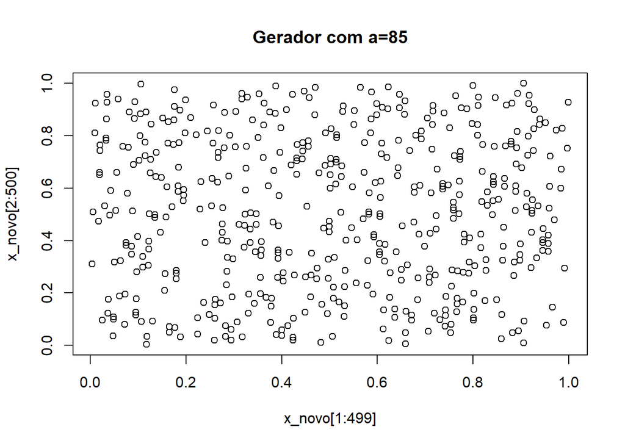

```r
plot(x_novo[1:499], x_novo[2:500], main="Gerador com a=85")
```

## Questão 7

Sejam $X_1, X_2 \sim N(0,1)$ variáveis aleatórias independentes e identicamente distribuídas (i.i.d.). Suas funções de densidade de probabilidade (f.d.p.) são dadas por:
$$f_{X_1}(x_1) = \frac{1}{\sqrt{2\pi}}
e^{-\frac{x_1^2}{2}} \quad \text{e} \quad f_{X_2}(x_2) =
\frac{1}{\sqrt{2\pi}} e^{-\frac{x_2^2}{2}}$$
Como $X_1$ e $X_2$ são independentes, a f.d.p. conjunta é o produto das densidades marginais:

$$f_{X_1, X_2}(x_1, x_2) = f_{X_1}(x_1)
\cdot f_{X_2}(x_2) = \frac{1}{2\pi} e^{-\frac{x_1^2 +
x_2^2}{2}}$$
Desejamos encontrar a densidade da variável $Y = \frac{X_1}{X_2}$. Utilizando a fórmula da densidade da razão para duas variáveis aleatórias, temos:
$$f_Y(y) = \int_{-\infty}^{\infty} |x_2| f_{X_1,
X_2}(y x_2, x_2) \, dx_2$$
Substituindo a densidade conjunta na integral, onde $x_1$ é substituído por $y x_2$:
$$f_Y(y) = \int_{-\infty}^{\infty} |x_2|
\frac{1}{2\pi} e^{-\frac{(yx_2)^2 + x_2^2}{2}} \, dx_2$$

Colocando $x_2^2$ em evidência no expoente:

$$f_Y(y) = \frac{1}{2\pi}
\int_{-\infty}^{\infty} |x_2| e^{-\frac{x_2^2(y^2 + 1)}{2}} \,
dx_2$$

Dada a simetria da função em relação a $x_2$, podemos integrar de $0$ a $\infty$ e multiplicar o resultado por 2:
$$f_Y(y) = \frac{2}{2\pi} \int_{0}^{\infty}
x_2 e^{-\frac{x_2^2(y^2 + 1)}{2}} \, dx_2$$

Para resolver esta integral, aplicamos a substituição:
$$u = \frac{x_2^2(y^2 + 1)}{2} \implies du =
x_2(y^2 + 1) \, dx_2 \implies x_2 \, dx_2 = \frac{du}{y^2 +
1}$$

Substituindo os termos na integral:
$$f_Y(y) = \frac{1}{\pi} \cdot \frac{1}{y^2 + 1}
\int_{0}^{\infty} e^{-u} \, du$$

Visto que $\int_{0}^{\infty} e^{-u} \, du = 1$, obtemos a f.d.p. final:
$$f_Y(y) = \frac{1}{\pi(1 + y^2)}$$

Esta expressão corresponde exatamente à função de densidade de probabilidade de uma distribuição da Cauchy padrão.

```r
gera_cauchy_normais <- function(n) {

  x1 <- rnorm(n)
  x2 <- rnorm(n)
  return(x1 / x2)
}
gera_cauchy_inv <- function(n) {
  u <- runif(n)

  x <- tan(pi * (u - 0.5))
  return(x)
}
```

```
## Tempo usando a inversa para uma amostra de tamanho 1e3: 0 segundos
## Tempo usando a normal padrão para uma amostra de tamanho 1e3: 0 segundos
```

Comecei aumentar tamanho da amostra pra ver como as funções se comportam

```
## Tempo usando a inversa para uma amostra de tamanho 1e4: 0.02 segundos
## Tempo usando a normal padrão para uma amostra de tamanho 1e4: 0.01 segundos
```

```
## Tempo usando a inversa para uma amostra de tamanho 1e5: 0.02 segundos
## Tempo usando a normal padrão para uma amostra de tamanho 1e5: 0.03 segundos
```

```
## Tempo usando a inversa para uma amostra de tamanho 1e6: 0.11 segundos
## Tempo usando a normal padrão para uma amostra de tamanho 1e6: 0.27 segundos
```

Concluimos emtão que o método da inversa é superior ao método do que a da padrão.

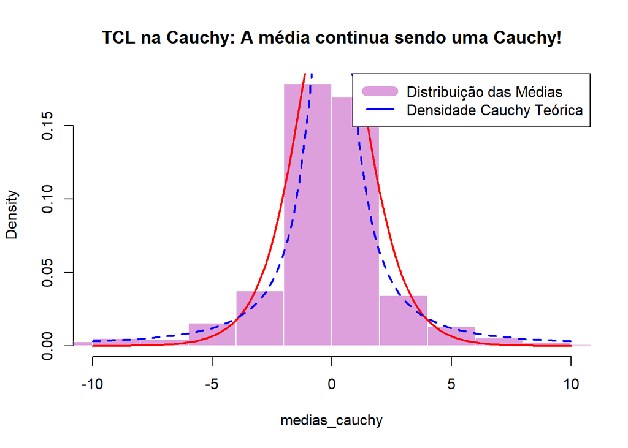

```r
n_medias <- 1e3
tamanho_amostra <- 1e3
medias_cauchy <- replicate(n_medias, mean(gera_cauchy_inv(tamanho_amostra)))

hist(medias_cauchy, breaks=500, freq=FALSE, xlim=c(-10, 10),
     main="TCL na Cauchy: A média continua sendo uma Cauchy!",
     col="plum", border="white")


curve(dlogis(x, 0, 1), add=TRUE, col="red", lwd=2)
curve(dcauchy(x, 0, 1), add=TRUE, col="blue", lwd=2, lty=2)

legend("topright", legend=c("Distribuição das Médias", "Densidade Cauchy Teórica"),
       col=c("plum", "blue"), lwd=c(10, 2))
```

## Questão 8

```r
a <- 2.7; b <- 6.3
f <- function(x){dbeta(x, a, b)}
n <- 1000

maximo <- optimize(f, interval = c(0,1), maximum = T)$objective

x1 <- runif(n)
y1 <- runif(n, 0, maximo)
aceito1 <- y1 <= f(x1)

cat("Proporção de aceitação da uniforme:", mean(aceito1))
```

```
## Proporção de aceitação da uniforme: 0.35
```

```r
g <- function(x){dbeta(x, 2, 6)}
maximo2 <- optimize(function(x){f(x)/g(x)}, interval=c(0,1), maximum=T)$objective

x2 <- rbeta(n, 2, 6)
y2 <- runif(n, 0, maximo2 * g(x2))
aceito2 <- y2 <= f(x2)

cat("Proporção ed aceitação beta(2,6):", mean(aceito2))
```

```
## Proporção ed aceitação beta(2,6): 0.576
```

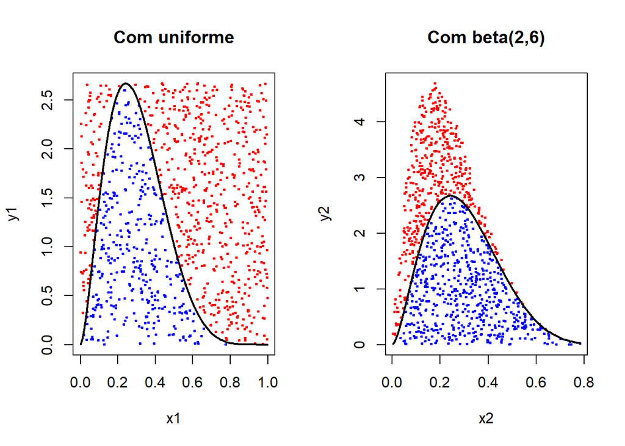

```r
par(mfrow = c(1, 2))

plot(x1, y1, col = ifelse(aceito1, "blue", "red"), pch = 20, cex = 0.5, main = "Com uniforme")
curve(f(x), add = T, lwd = 2)

plot(x2, y2, col = ifelse(aceito2, "blue", "red"), pch = 20, cex = 0.5, main = "Com beta(2,6)")
curve(f(x), add = T, lwd = 2)
```

## Questão 9

```r
n <- 1000
L <- 0.05

#método da inversa
metodo <- function(n){
  u <- runif(n)
  x_simulado <- -log(1 - u*(1 - exp(-L)))
  esperanca_estimada <- mean(x_simulado)

  return(esperanca_estimada)
}
rtd <- metodo(n)
cat("A esperança estimada é", rtd)
```

```
## A esperança estimada é 0.02477362
```

```r
valor_exato <- (1 - (1 + L)*exp(-L))/(1 - exp(-L))

cat("Valor exato:", valor_exato, "\n")
```

```
## Valor exato: 0.02479168
```

```r
cat("Diferença absoluta:", abs(rtd - valor_exato))
```

```
## Diferença absoluta: 1.805663e-05
```

## Questão 10

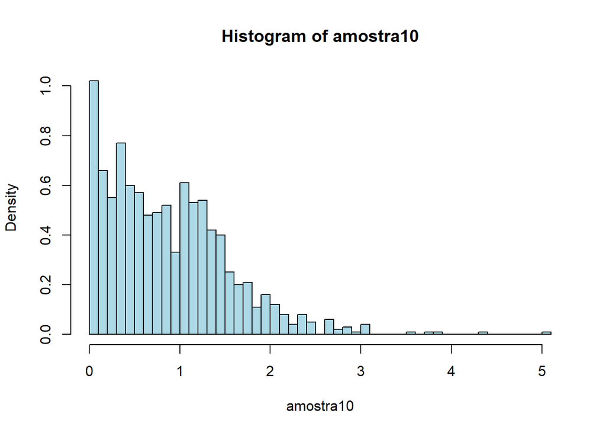

```r
gera_10 <- function(n) {
  x_final <- numeric(n)

  for(i in 1:n) {
    sucesso <- FALSE
    while(!sucesso) {
      u1 <- runif(1)
      if(u1 < 2/3) {

        candidato <- runif(1)
        if(runif(1) < (1 + exp(-2*candidato))/2) {
          x_final[i] <- candidato
          sucesso <- TRUE
        }
      } else {
        x_final[i] <- 1 + rexp(1, rate = 2)
        sucesso <- TRUE
      }
    }
  }
  return(x_final)
}

amostra10 <- gera_10(1e3)
hist(amostra10, breaks=50, prob=TRUE, col="lightblue")
```